# Odhadování počtu cest v grafech

Psychofyzikální experiment

Autoři

Šimon Jukl

Michal Hužva

Publikováno

květen 2026

**Kód**

```r
sessioncheck::sessioncheck()
library(here)
library(tidyverse)

library(scales)

library(knitr)
library(kableExtra)

library(cmdstanr)
library(brms)
library(posterior)
library(tidybayes)
library(bayesplot)
library(priorsense)

set.seed(42)

source(here("utils.R"))

update <- FALSE
if (!file.exists(here("data/clean/data_clean.csv")) | update) {
  source(here("data/data_prep.R"))
}
d0 <- read_csv(here("data/clean/data_clean.csv"))

# source(here("simulation/run_sim.R"))
sim_results <- read_rds(here("simulation/sim_results.rds"))

knitr::opts_chunk$set(dev = 'ragg_png')

theme_custom <-
  theme_minimal(base_size = 12) +
  theme(
    panel.grid = element_blank(),

    axis.line = element_line(color = "black", linewidth = .5),
    axis.ticks = element_line(linewidth = .5),

    axis.text = element_text(size = 8, color = "black"),
    axis.text.x = element_text(margin = margin(t = 10)),
    axis.title.y = element_text(margin = margin(r = 10)),
  )

theme_dist <- list(
  theme(
    axis.text.y = element_blank(),
    axis.ticks.y = element_blank(),
    axis.line.y = element_blank()
  ),
  labs(y = NULL)
)

theme_set(theme_custom)

options(brms.backend = "cmdstanr")
options(mc.cores = 4)
options(digits = 3)
options(scipen = 5)
options(warn = 1)

.ndraws = 40
n_sim <- 1000
```

**Kód**

```r
d <-
  d0 |>
  filter_out(when_any(
    block == "practice",
    # filter out typos or unreasonable responses
    response > 20,
    is.na(response),
    is.na(rt)
  )) |>
  mutate(
    e = standardize(n_edges),
    l = standardize(n_loops),
    p = standardize(n_paths),
    t = standardize(duration)
  )
```

**Kód**

```r
p_vals <- sort(unique(d$p))
t_vals <- sort(unique(d$t))
l_vals <- sort(unique(d$l))

p_labels <- sort(unique(d$n_paths))
t_labels <- sort(unique(d$duration))
l_labels <- sort(unique(d$n_loops))

lab_id <- as_labeller(\(x) paste("ID: ", x))
lab_t <- as_labeller(\(x) {
  orig <- as.numeric(x) * attr(d$t, "scaled:scale") + attr(d$t, "scaled:center")
  paste("Doba:", round(orig, 1), "s")
})
lab_p <- as_labeller(\(x) {
  orig <- as.numeric(x) * attr(d$p, "scaled:scale") + attr(d$p, "scaled:center")
  paste("Počet cest:", round(orig, 1))
})
lab_l <- as_labeller(\(x) {
  orig <- as.numeric(x) * attr(d$l, "scaled:scale") + attr(d$l, "scaled:center")
  paste("Počet smyček:", round(orig, 1))
})
```

# Úvod

V tomto experimentu měli participanti za úkol odhadovat, kolik unikátních cest viděli ve čtvercovém 4x4 neorientovaném grafu (viz Obrázek 1).

**Kód**

Obrázek 1

Příklad grafu

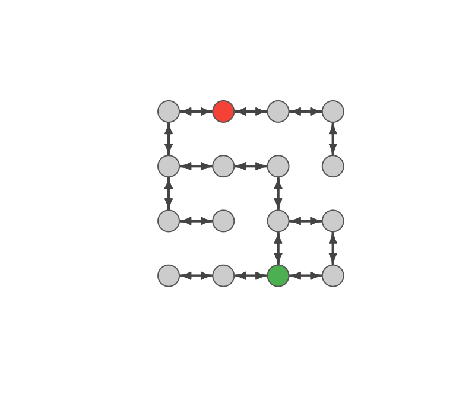

```r
d |>
  slice_sample(n = 1) |>
  as_plot_row() |>
  plot_row()
```

Grafy se lišily těmito parametery:

- počet cest (1, 7)
- počet hran (15, 19)
- počet smyček (0, 4)

# Vlastnosti grafů a simulace

K prozkoumání vlastností grafů před administrací byly použity simulace.

V jednoduchém grafu, kde jsou všechny uzly spojeny pouze se sousedními uzly nediagonálně, může být maximálně

$$(x - 1) \cdot y + x \cdot (y - 1)$$

hran, kde $x$ a $y$ jsou počet řádek a sloupců (počet uzlů v každé dimenzi), což se pro čtvercový graf zjednoduší na

$$2 \cdot x \cdot (x - 1).$$

V našem případě pro graf o velikosti 4 je to tedy $2 \cdot 4 \cdot (4 - 1) = 24$.

Pro graf orientovaný, tedy s jednosměrnými spojy mezi uzly, by tento počet byl dvojnásobný.

Pokud jde o počet smyček, ten je v našem rozsahu plně determinován počtem hran. Minimální počet hran, kterým lze propojit graf, je 15, což implikuje absenci smyček, které vytvářejí nadbytečné spoje. Maximální počet hran, 19, koresponduje ke 4 smyčkám.

## Stanovení rozsahů parametrů

Grafy byly generovány pomocí stanovení minimálního a maximálního počtu hran a cílového počtu cest v grafu.

**Kód**

Obrázek 2

Rozložení četnosti počtu hran podle cílového počtu cest

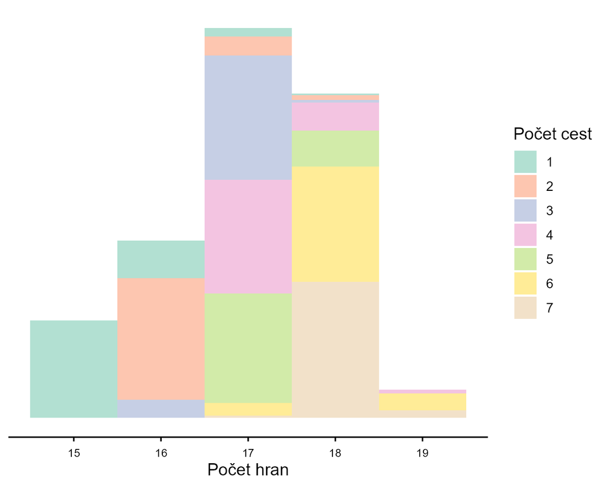

```r
sim_results |>
  filter(!is.na(n_paths)) |>
  ggplot(aes(x = n_edges, fill = factor(target_n_paths))) +
  geom_histogram(binwidth = 1, position = "stack", alpha = 0.5) +
  scale_fill_brewer(palette = "Set2", name = "Počet cest") +
  scale_x_continuous(breaks = scales::breaks_width(1), name = "Počet hran") +
  scale_y_continuous(breaks = NULL) +
  theme_dist
```

Obrázek 2 zobrazuje zásadní omezení, tedy že po překročení 19 hran začně minimální možný počet cest zásadně narůstat. Je nám tedy stanovena limitace na počet cest jako 7 a méně. Na základě pilotáže jsme usoudili, že pro krátce prezetované grafy stejně není vyšší počet cest vyhovující.

Na obrázcích níže lze vidět vztah cest s hranami (Obrázek 3) a smyčkami (Obrázek 4), respektive jejich ekvivalence.

**Kód**

Obrázek 3

Počet cest v závislosti na počtu hran

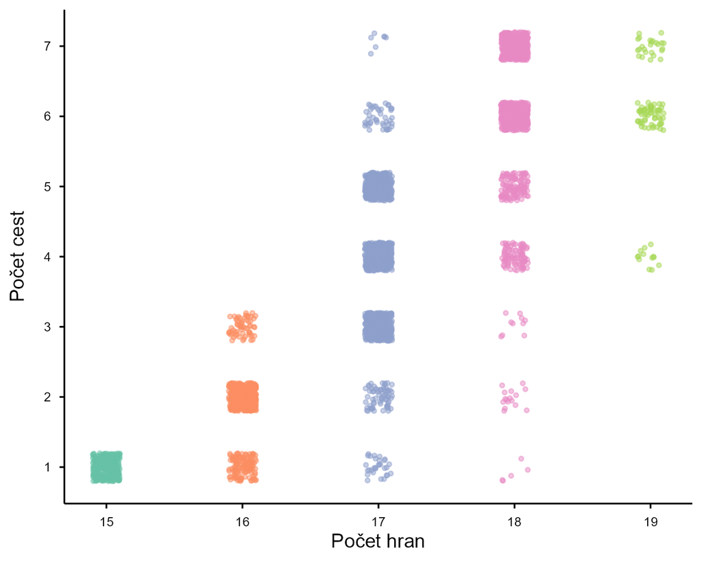

```r
sim_results |>
  filter(!is.na(n_paths)) |>
  ggplot(aes(x = n_edges, y = n_paths, color = factor(n_loops))) +
  geom_jitter(width = 0.1, height = 0.2, alpha = 0.5, size = 1) +
  scale_x_continuous(breaks = breaks_width(1)) +
  scale_y_continuous(breaks = breaks_width(1)) +
  scale_color_brewer(palette = "Set2", name = "Počet smyček") +
  labs(
    x = "Počet hran",
    y = "Počet cest"
  ) +
  guides(color = "none")
```

**Kód**

Obrázek 4

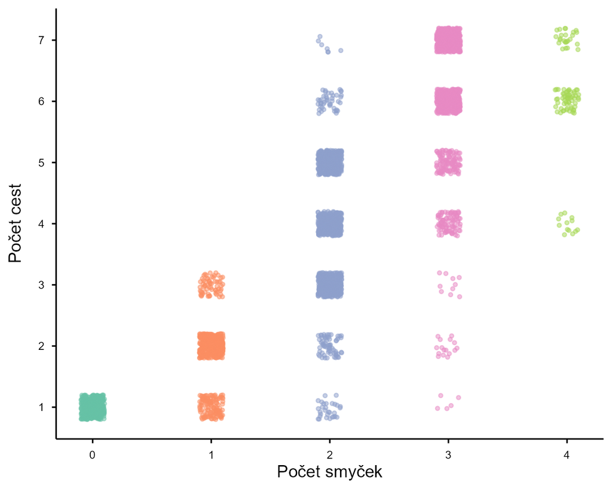

```r
sim_results |>
  filter(!is.na(n_paths)) |>
  ggplot(aes(x = n_loops, y = n_paths, colour = factor(n_edges))) +
  geom_jitter(width = 0.1, height = 0.2, alpha = 0.5, size = 1) +
  scale_x_continuous(breaks = 0:12) +
  scale_y_continuous(breaks = breaks_width(1)) +
  scale_color_brewer(palette = "Set2", name = "Počet hran") +
  labs(
    x = "Počet smyček",
    y = "Počet cest"
  ) +
  guides(color = "none")
```

# Design

- 10/20 trénovacích trialů
- 1, 3, 5 sekund prezentace stimulu
- 9 x 1 až 7 cest = 63 trialů ()
- 3 bloky x 63 trialů
- po prezentaci 5 s na odpověď

# Deskriptivní statistika

## Chybějící hodnoty

**Kód**

```r
d0 |>
  filter_out(block == "practice") |>
  summarize(n_na = sum(is.na(response)), .by = c(id, block)) |>
  arrange(id, block) |>
  pivot_wider(id_cols = id, names_from = block, values_from = n_na) |>
  rename(ID = id) |>
  kable_apa() |>
  add_header_above(c(" " = 1, "Block" = 3), align = "l")
```

Tabulka 1

| ID | Block 1 | Block 2 | Block 3 |
| --- | --- | --- | --- |
| 01 | 0 | 0 | 1 |
| 02 | 0 | 0 | 0 |
| 03 | 0 | 0 | 0 |
| 04 | 0 | 0 | 0 |

## Rychlost odpovědi

**Kód**

Obrázek 5

Rychlost odpovědi podle doby trvání stimulu

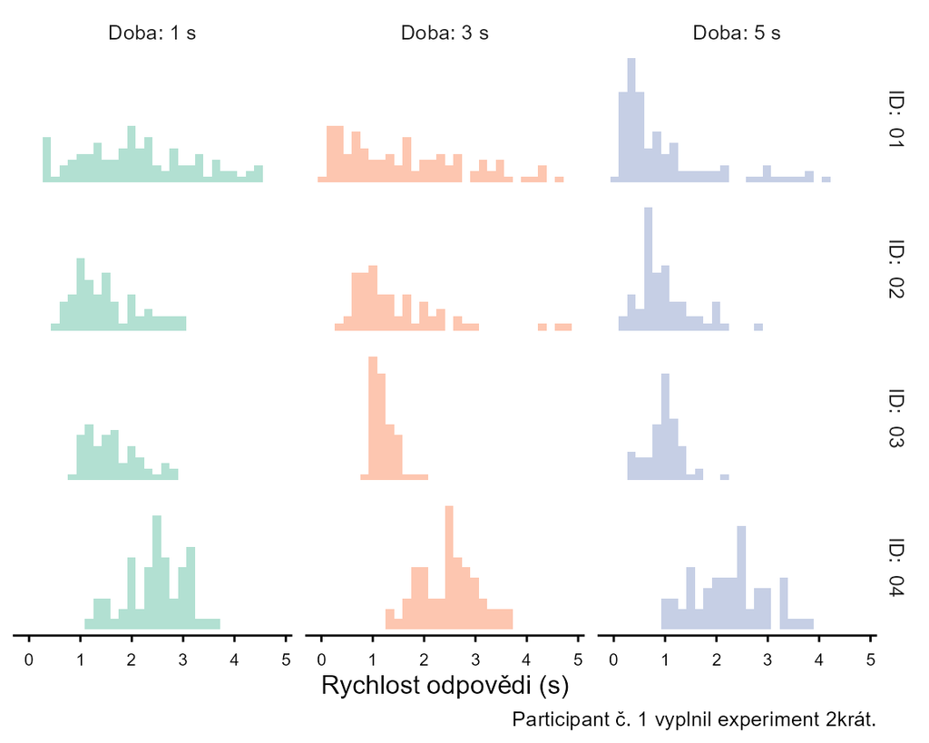

```r
d |>
  ggplot(aes(rt, fill = factor(duration))) +
  geom_histogram(alpha = 0.5) +
  facet_grid(
    id ~ t,
    scales = "free_y",
    labeller = labeller(
      id = lab_id,
      t = lab_t
    )
  ) +
  scale_x_continuous(breaks = breaks_width(1), name = "Rychlost odpovědi (s)") +
  scale_fill_brewer(palette = "Set2", guide = "none") +
  theme_dist +
  labs(caption = "Participant č. 1 vyplnil experiment 2krát.")
```

## Odpovědi

**Kód**

Obrázek 6

Odpovědi podle reálného počtu cest

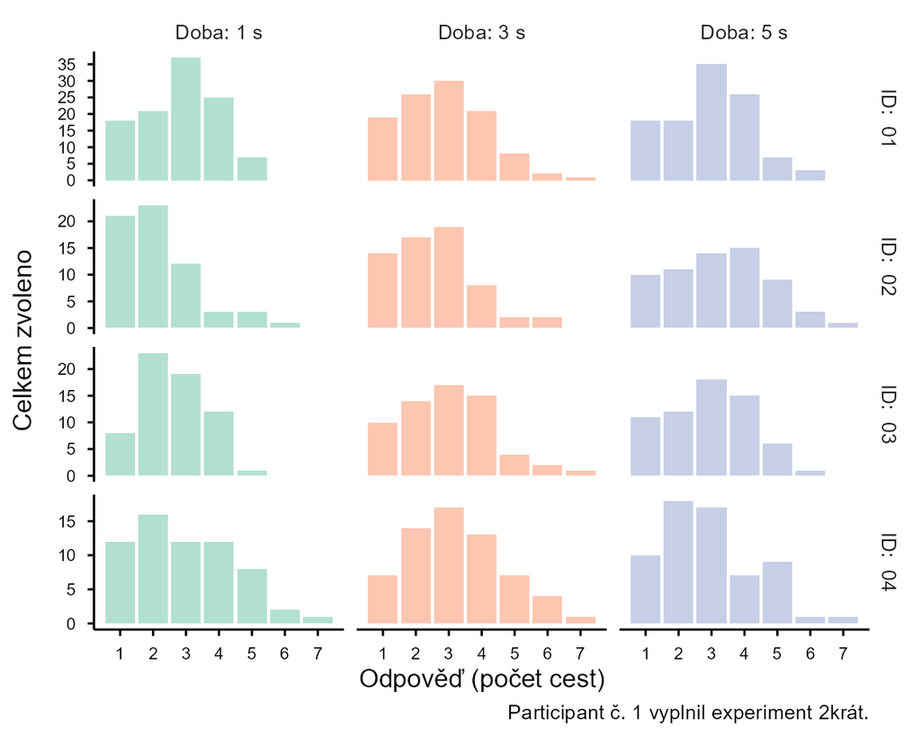

```r
d |>
  ggplot(aes(response, fill = factor(duration))) +
  geom_bar(alpha = 0.5) +
  facet_grid(
    id ~ t,
    scales = "free_y",
    labeller = labeller(
      id = lab_id,
      t = lab_t
    )
  ) +
  scale_x_continuous(breaks = breaks_width(1), name = "Odpověď (počet cest)") +
  scale_y_continuous(breaks = breaks_width(5), name = "Celkem zvoleno") +
  scale_fill_brewer(palette = "Set2", guide = "none") +
  labs(caption = "Participant č. 1 vyplnil experiment 2krát.")
```

**Kód**

Obrázek 7

Správné odpovědi podle reálného počtu cest

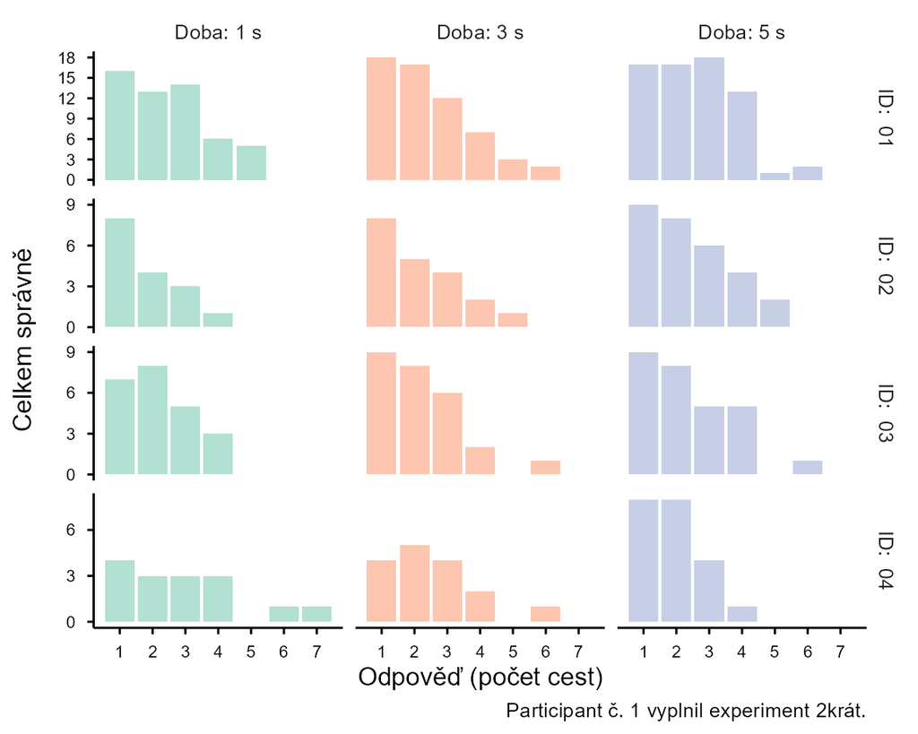

```r
# d |>
#   ggplot(aes(response, correct, fill = factor(duration))) +
#   geom_col(alpha = 0.5) +
#   facet_wrap(vars(duration)) +
#   scale_x_continuous(breaks = breaks_width(1), name = "Odpověď (počet cest)") +
#   scale_fill_brewer(palette = "Set2", name = "Trvání stimulu (s)") +
#   theme_dist

d |>
  ggplot(aes(response, correct, fill = factor(duration))) +
  geom_col(alpha = 0.5) +
  facet_grid(
    id ~ t,
    scales = "free_y",
    labeller = labeller(
      id = lab_id,
      t = lab_t
    )
  ) +
  scale_x_continuous(breaks = breaks_width(1), name = "Odpověď (počet cest)") +
  scale_y_continuous(breaks = breaks_width(3), name = "Celkem správně") +
  scale_fill_brewer(palette = "Set2", guide = "none") +
  labs(caption = "Participant č. 1 vyplnil experiment 2krát.")
```

**Kód**

Obrázek 8

Reakční čas podle odpovědi a doby trvání stimulu

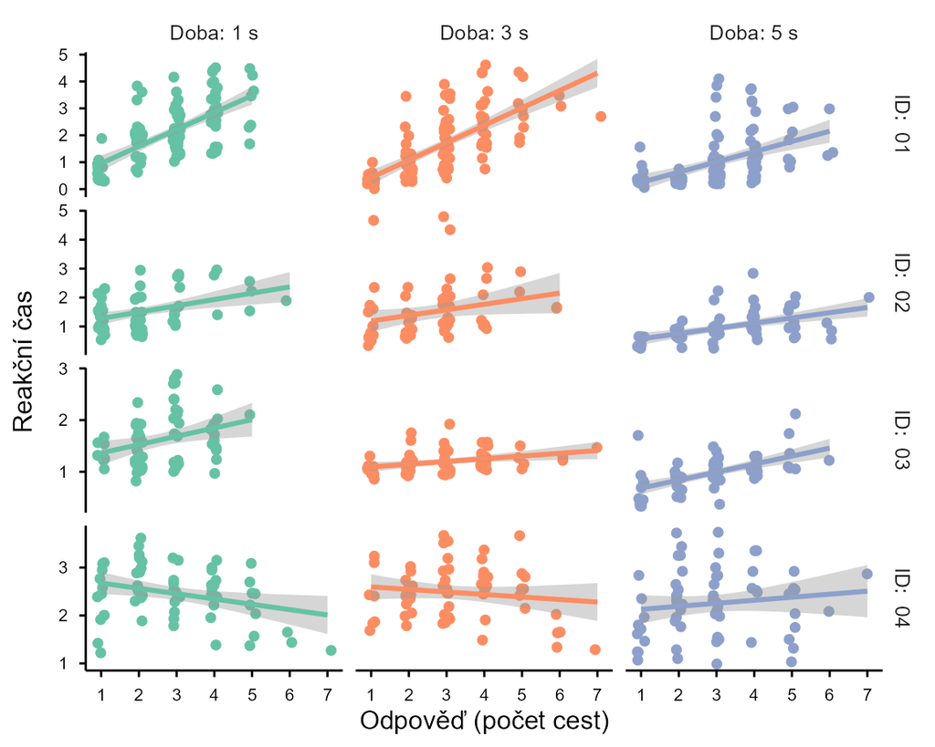

```r
d |>
  ggplot(aes(response, rt, color = factor(duration))) +
  geom_jitter(width = 0.1, height = 0) +
  geom_smooth(method = "lm") +
  # facet_wrap(vars(id)) +
  facet_grid(
    id ~ t,
    scales = "free_y",
    labeller = labeller(
      id = lab_id,
      t = lab_t
    )
  ) +
  scale_x_continuous(breaks = breaks_width(1), name = "Odpověď (počet cest)") +
  scale_y_continuous(breaks = breaks_width(1), name = "Reakční čas") +
  scale_color_brewer(palette = "Set2", guide = "none")
```

**Kód**

Obrázek 9

Vztah odpovědí, počtu cest a doby trvání stimulu

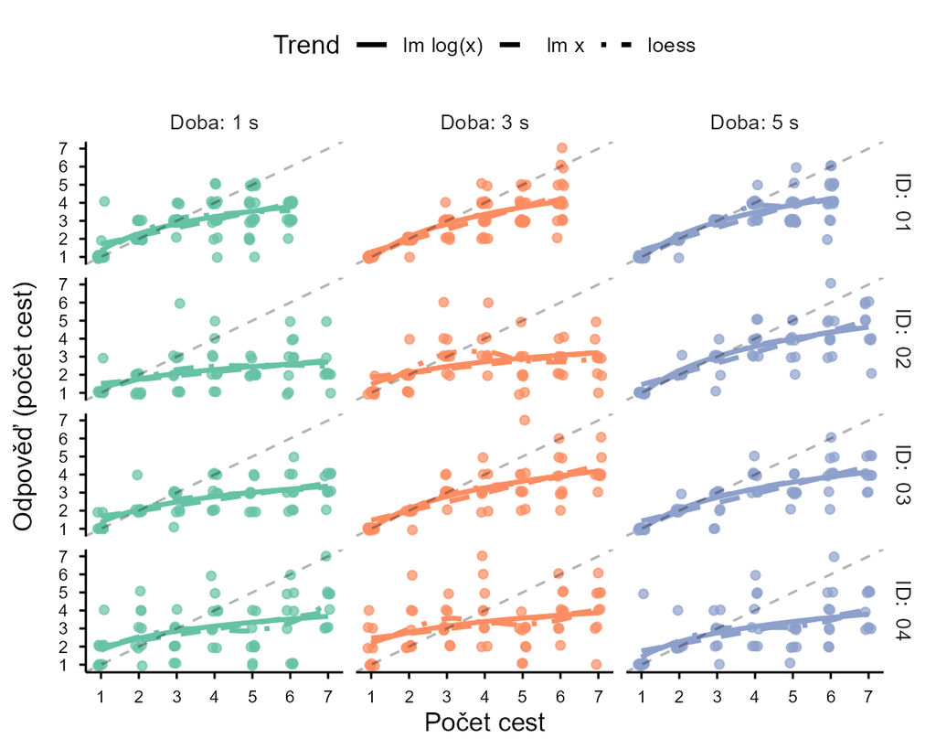

```r
d |>
  ggplot(aes(n_paths, response, color = factor(duration))) +
  geom_jitter(width = 0.1, height = 0.1, alpha = 0.7) +
  geom_smooth(
    aes(linetype = "lm log(x)"),
    method = "lm",
    formula = y ~ log(x),
    se = FALSE
  ) +
  geom_smooth(
    aes(linetype = "lm x"),
    method = "lm",
    formula = y ~ x,
    se = FALSE
  ) +
  geom_smooth(
    aes(linetype = "loess"),
    method = "loess",
    formula = y ~ x,
    se = FALSE
  ) +
  geom_abline(linetype = 2, alpha = 0.3) +
  # facet_wrap(vars(id)) +
  facet_grid(
    id ~ t,
    # scales = "free_y",
    labeller = labeller(
      id = lab_id,
      t = lab_t
    )
  ) +
  scale_x_continuous(breaks = breaks_width(1), name = "Počet cest") +
  scale_y_continuous(breaks = breaks_width(1), name = "Odpověď (počet cest)") +
  scale_color_brewer(palette = "Set2", guide = "none") +
  scale_linetype_manual(
    name = "Trend",
    values = c("lm log(x)" = "solid", "lm x" = "dashed", "loess" = "dotdash"),
  ) +
  guides(linetype = guide_legend(override.aes = list(color = "black"))) +
  theme(legend.position = "top")
```

**Kód**

Obrázek 10

Vztah odpovědí, počtu smyček a doby trvání stimulu

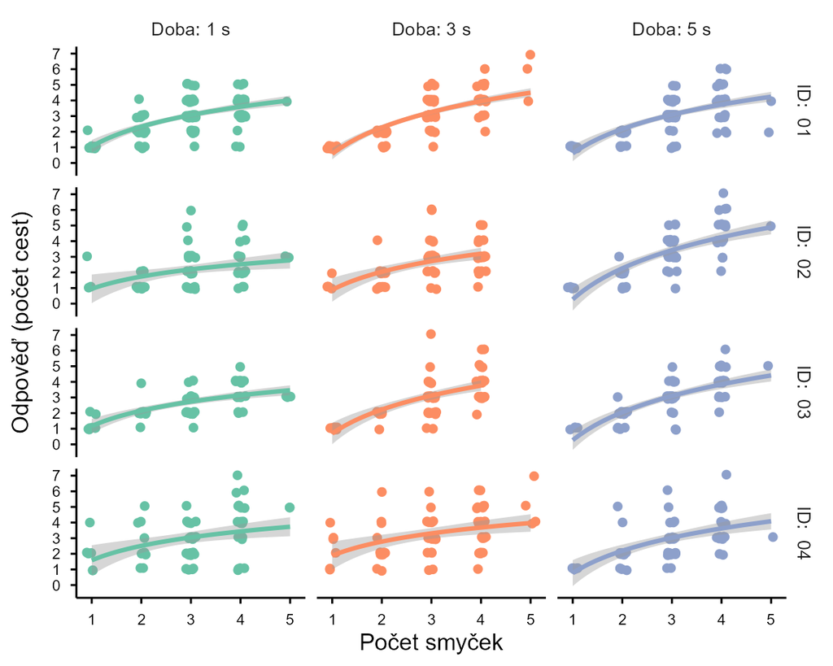

```r
d |>
  ggplot(aes(n_loops + 1, response, color = factor(duration))) +
  geom_jitter(width = 0.1, height = 0.1) +
  geom_smooth(method = "lm", formula = y ~ log(x)) +
  # geom_abline(linetype = 2, alpha = 0.5) +
  # facet_wrap(vars(id)) +
  facet_grid(
    id ~ t,
    # scales = "free_y",
    labeller = labeller(
      id = lab_id,
      t = lab_t
    )
  ) +
  scale_x_continuous(breaks = breaks_width(1), name = "Počet smyček") +
  scale_y_continuous(breaks = breaks_width(1), name = "Odpověď (počet cest)") +
  scale_color_brewer(palette = "Set2", guide = "none")
```

# Modely

- Poissonova (log-lineární) regrese
- všechny prediktory jsou vycentrované
- $y$ je odpověď participanta
- $p$ je počet cest
- $t$ je doba prezentace stimulu
- $l$ je počet smyček

## Model 1: Cesty a doba trvání

$$\begin{align*}
y_i &\sim \text{Poisson}(\lambda_i) \\
\log \lambda_i &= \beta_0 +
\beta_{p} (p_i - \overline{p}) +
\beta_{t} (t_i - \overline{t}) \\
\beta_0 &\sim \operatorname{Normal}(\log \overline{p}, 0.2) \\
\beta_{p} &\sim \operatorname{Normal}(0.1, 0.2) \\
\beta_{t} &\sim \operatorname{Normal}(0, 0.1)
\end{align*}$$

**Kód**

```r
prior1 <- c(
  set_prior(str_glue("normal(1.3, 0.2)"), class = "b", coef = "Intercept"),
  set_prior("normal(0.1, 0.2)", class = "b", coef = "p"),
  set_prior("normal(0, 0.1)", class = "b", coef = "t")
)

fit1 <- brm(
  formula = bf(response ~ 0 + Intercept + p + t),
  data = d,
  family = poisson(),
  prior = prior1,
  seed = 42,
  file = here("results/fits/fit1.rds")
)

fit1
```

```
 Family: poisson
  Links: mu = log
Formula: response ~ 0 + Intercept + p + t
   Data: d (Number of observations: 888)
  Draws: 4 chains, each with iter = 2000; warmup = 1000; thin = 1;
         total post-warmup draws = 4000

Regression Coefficients:
          Estimate Est.Error l-95% CI u-95% CI Rhat Bulk_ESS Tail_ESS
Intercept     1.01      0.02     0.97     1.05 1.00     3248     3008
p             0.28      0.02     0.24     0.32 1.00     3502     2969
t             0.05      0.02     0.01     0.08 1.00     3960     2839

Draws were sampled using sample(hmc). For each parameter, Bulk_ESS
and Tail_ESS are effective sample size measures, and Rhat is the potential
scale reduction factor on split chains (at convergence, Rhat = 1).
```

Model dovoluje nulu, což neodpovídá našim podmínkám.

**Kód**

Obrázek 11

Posteriorní predikce (tmavě) vs. reálná data (světlé sloupce)

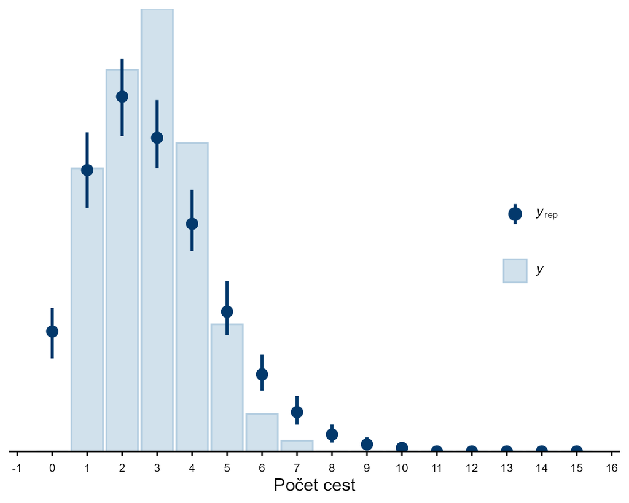

```r
pp_check(fit1, type = "bars", ndraws = 200) +
  scale_x_continuous(breaks = breaks_width(1), name = "Počet cest") +
  theme_dist +
  theme(legend.position = "inside", legend.justification = c(0.9, 0.5))
```

## Model 2: Zero-truncated Poisson

Všechny následující modely používají zero-truncated Poissonovu regresi, která omezuje možné odpovědi dolní hranicí na jedna a více, tedy nedovoluje nulu.

$$\begin{align*}
y_i &\sim \text{ZTPoisson}(\lambda_i) \\
\log \lambda_i &= \beta_0 +
\beta_{p} (p_i - \overline{p}) +
\beta_{t} (t_i - \overline{t}) \\
\beta_0 &\sim \operatorname{Normal}(\log \overline{p}, 0.2) \\
\beta_{p} &\sim \operatorname{Normal}(0.1, 0.2) \\
\beta_{t} &\sim \operatorname{Normal}(0, 0.1)
\end{align*}$$

**Kód**

```r
fit2 <- brm(
  formula = bf(response | trunc(lb = 1) ~ 0 + Intercept + p + t),
  data = d,
  family = poisson(),
  prior = prior1,
  seed = 42,
  file = here("results/fits/fit2.rds")
)

fit2
```

```
 Family: poisson
  Links: mu = log
Formula: response | trunc(lb = 1) ~ 0 + Intercept + p + t
   Data: d (Number of observations: 888)
  Draws: 4 chains, each with iter = 2000; warmup = 1000; thin = 1;
         total post-warmup draws = 4000

Regression Coefficients:
          Estimate Est.Error l-95% CI u-95% CI Rhat Bulk_ESS Tail_ESS
Intercept     0.90      0.02     0.85     0.95 1.00     2792     2852
p             0.36      0.02     0.31     0.40 1.00     3172     2816
t             0.06      0.02     0.01     0.10 1.00     3352     2580

Draws were sampled using sample(hmc). For each parameter, Bulk_ESS
and Tail_ESS are effective sample size measures, and Rhat is the potential
scale reduction factor on split chains (at convergence, Rhat = 1).
```

Tento model pasuje o něco lépe, bohužel stále vidíme odchylky kvůli parametrizaci Poissonovy regrese, ve které je parametr $\lambda$ jak očekávanou hodnotou, tak mírou rozptylu. Zde pak dochází k tomu, že aby model vyhověl rozptylu dat, snižuje lambdu, čímž však dostává očekávanou hodnotu pod reálný peak dat.

**Kód**

Obrázek 12

Posteriorní predikce (tmavě) vs. reálná data (světlé sloupce)

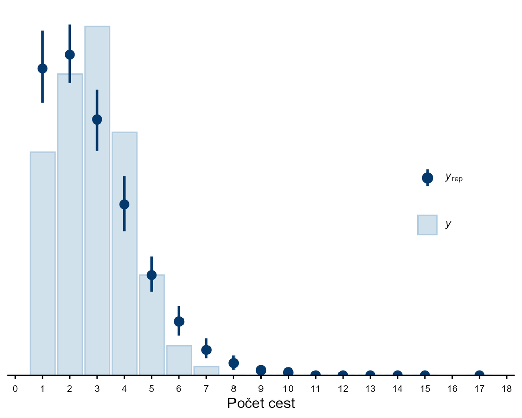

```r
pp_check(fit2, type = "bars", ndraws = 200) +
  scale_x_continuous(breaks = breaks_width(1), name = "Počet cest") +
  theme_dist +
  theme(legend.position = "inside", legend.justification = c(0.9, 0.5))
```

## Model 3: Varying effects

$$\begin{align*}
y_i &\sim \text{ZTPoisson}(\lambda_i) \\
\log \lambda_i &= \beta_0 + u_{0,\text{id}[i]} +
(\beta_{p} + u_{p,\text{id}[i]}) (p_i - \overline{p}) +
(\beta_{t} + u_{t,\text{id}[i]}) (t_i - \overline{t}) \\
\beta_0 &\sim \operatorname{Normal}(\log \overline{p}, 0.2) \\
\beta_{p} &\sim \operatorname{Normal}(0.1, 0.2) \\
\beta_{t} &\sim \operatorname{Normal}(0, 0.1) \\
\begin{pmatrix} u_{0,j} \\ u_{p,j} \\ u_{t,j} \end{pmatrix} &\sim \operatorname{MVNormal}(\mathbf{0},\, \mathbf{S}) \\
\mathbf{S} &= \operatorname{diag}(\sigma) \, \mathbf{R} \, \operatorname{diag}(\sigma) \\
\sigma &\sim \operatorname{Student-t}(3, 0, 0.2) \\
\mathbf{R} &\sim \operatorname{LKJ}(2)
\end{align*}$$

**Kód**

```r
prior3 <- c(
  prior1,
  set_prior("lkj(2)", class = "cor", group = "id"),
  set_prior(
    "student_t(3, 0, 0.2)",
    class = "sd",
    coef = "Intercept",
    group = "id"
  ),
  set_prior("student_t(3, 0, 0.2)", class = "sd", coef = "p", group = "id"),
  set_prior("student_t(3, 0, 0.2)", class = "sd", coef = "t", group = "id")
)

fit3 <- brm(
  formula = bf(
    response | trunc(lb = 1) ~ 0 + Intercept + p + t + (1 + p + t | id)
  ),
  data = d,
  family = poisson(),
  prior = prior3,
  seed = 42,
  file = here("results/fits/fit3.rds"),
  control = list(adapt_delta = 0.95)
)

fit3
```

```
 Family: poisson
  Links: mu = log
Formula: response | trunc(lb = 1) ~ 0 + Intercept + p + t + (1 + p + t | id)
   Data: d (Number of observations: 888)
  Draws: 4 chains, each with iter = 2000; warmup = 1000; thin = 1;
         total post-warmup draws = 4000

Multilevel Hyperparameters:
~id (Number of levels: 4)
                 Estimate Est.Error l-95% CI u-95% CI Rhat Bulk_ESS Tail_ESS
sd(Intercept)        0.14      0.09     0.03     0.36 1.00     1409     1268
sd(p)                0.14      0.08     0.04     0.35 1.00     1530     1912
sd(t)                0.11      0.06     0.02     0.27 1.00     1855     1642
cor(Intercept,p)    -0.02      0.37    -0.69     0.66 1.00     2571     2656
cor(Intercept,t)    -0.30      0.37    -0.89     0.46 1.00     3136     2616
cor(p,t)            -0.02      0.36    -0.70     0.66 1.00     3249     3325

Regression Coefficients:
          Estimate Est.Error l-95% CI u-95% CI Rhat Bulk_ESS Tail_ESS
Intercept     0.94      0.08     0.80     1.14 1.00     1647     1699
p             0.33      0.08     0.14     0.46 1.00     1869     1904
t             0.05      0.05    -0.07     0.14 1.00     2299     2583

Draws were sampled using sample(hmc). For each parameter, Bulk_ESS
and Tail_ESS are effective sample size measures, and Rhat is the potential
scale reduction factor on split chains (at convergence, Rhat = 1).
```

Hierarchický model problémy s nadhodnocováním variance neřeší, je však dalším logickým krokem při tvorbě modelu.

**Kód**

Obrázek 13

Posteriorní predikce (tmavě) vs. reálná data (světlé sloupce)

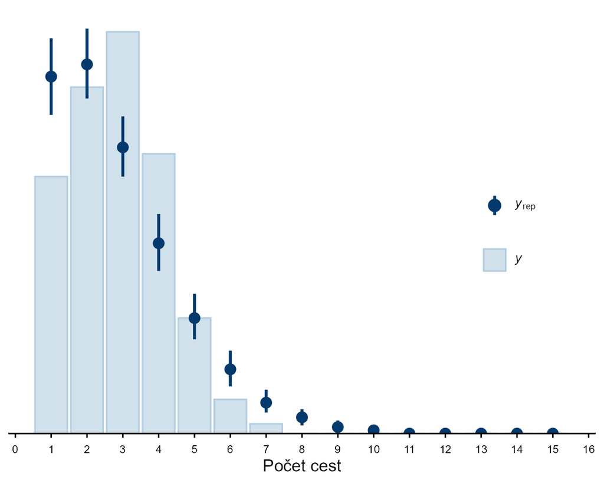

```r
pp_check(fit3, type = "bars", ndraws = 200) +
  scale_x_continuous(breaks = breaks_width(1), name = "Počet cest") +
  theme_dist +
  theme(legend.position = "inside", legend.justification = c(0.9, 0.5))
```

## Model 4: Conway-Maxwell Poisson (COMP)

Tento model byl pokus o řešení nadhodnoceného rozptylu u Poissonovy regrese, avšak se nepodařilo ho dobře parametrizovat a byl tedy vyřazen.

## Model 5: Reziduály smyček

Do modelu byly přidány reziduály počtu smyček po OLS regresi na počet cest. Tento výpočet reziduálů je pouze aproximace, jelikož nezohledňuje celou nejistotu posteriorní distribuce reziduálů, ale pouze jejich OLS odhad. Je tedy možné nadhodnocení prediktičních schopností modelu.

### Implikace priorů

Prior pro $\beta_0$ (průsečík lineárního prediktoru) je vycentrovaný na logaritmu zaokrouhleného průměru počtu cest v datech. Tento prior je agnostický vůči směru efektu a naznačuje linární vztah.

Prior pro $\beta_p$ je mírně pozitivní, jelikož očekáváme vyšší odhad počtu cest se zvyšujícím se reálným počtem cest.

Prior $\beta_{lr}$ je vycentrovaný na nule. Dopředu neočekáváme směr efektu reziduálů smyček po kontrole počtu cest. Priorní distribuce pro hyperparametry ($\sigma_{\text{id}}$) nechávají místo pro individuální rozdíly i v extrémech.

Reziduály smyček lze intepretovat jako (standardizovaný) počet smyček vyšší (nebo menší), než by v grafu predikoval počet cest. Interpretace jejich koeficientů je tedy efekt “nadbytečných” smyček na odhadovaný počet cest.

**Kód**

```r
# random draws from zero-truncated poisson (resample when 0)
rztpois <- function(n, lambda) {
  x <- rpois(n, lambda)
  while (any(x == 0)) {
    x[x == 0] <- rpois(sum(x == 0), lambda[x == 0])
  }
  x
}
```

**Kód**

```r
d <- d |>
  mutate(
    lr = residuals(lm(l ~ p, data = d))
  )

lr_vals <- quantile(unique(d$lr), probs = c(0.1, 0.5, 0.9))

lab_lr <- as_labeller(\(x) {
  # orig <- as.numeric(x) * attr(d$lr, "scaled:scale") + attr(d$lr, "scaled:center")
  paste("Rezid. smyček:", round(lr_vals * sd(d$n_loops), 1))
})


prior_draws5 <-
  tibble(
    .draw = 1:n_sim,
    b_Intercept = rnorm(n_sim, 1.3, 0.2),
    b_p = rnorm(n_sim, 0.1, 0.2),
    b_t = rnorm(n_sim, 0.0, 0.1),
    b_lr = rnorm(n_sim, 0.01, 0.1),
    sd_id__Intercept = abs(rt(n_sim, df = 3) * 0.1),
    sd_id__p = abs(rt(n_sim, df = 3) * 0.1),
    sd_id__t = abs(rt(n_sim, df = 3) * 0.1),
    sd_id__lr = abs(rt(n_sim, df = 3) * 0.1)
  ) |>
  as_draws_df() |>
  expand_grid(id = sort(unique(d$id)), p = p_vals, t = t_vals, lr = lr_vals) |>
  mutate(
    u_Intercept = rnorm(n(), 0, sd_id__Intercept),
    u_p = rnorm(n(), 0, sd_id__p),
    u_t = rnorm(n(), 0, sd_id__t),
    u_lr = rnorm(n(), 0, sd_id__lr),
    linpred = b_Intercept +
      u_Intercept +
      (b_p + u_p) * p +
      (b_t + u_t) * t +
      (b_lr + u_lr) * lr,
    epred = exp(linpred),
    predicted = rztpois(n(), epred)
  )
```

**Kód**

Obrázek 14

Očekávaný odhad a priori (Model 5)

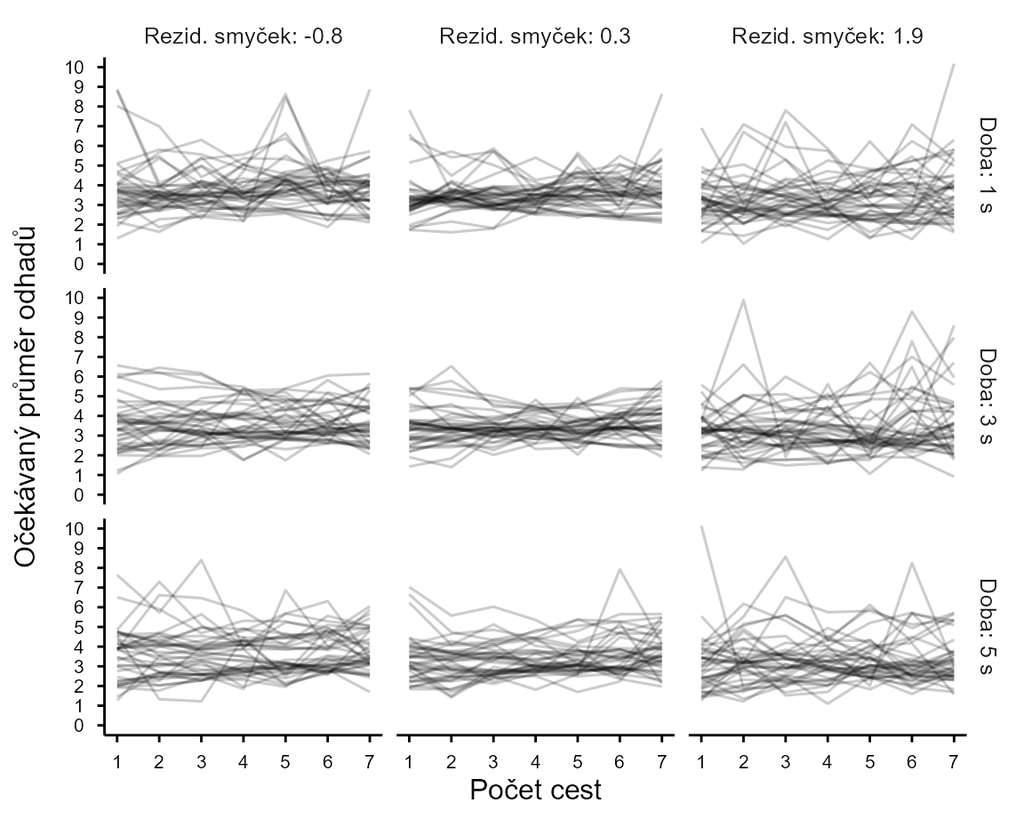

```r
prior_draws5 |>
  sample_draws(ndraws = .ndraws / 4) |>
  ggplot(aes(p, epred, group = interaction(.draw, id))) +
  geom_line(alpha = 0.2) +
  facet_grid(t ~ lr, labeller = labeller(t = lab_t, lr = lab_lr)) +
  scale_x_continuous(breaks = p_vals, labels = p_labels, name = "Počet cest") +
  scale_y_continuous(
    breaks = breaks_width(1),
    name = "Očekávaný průměr odhadů"
  ) +
  coord_cartesian(ylim = c(0, 10))
```

**Kód**

```r
prior_draws5 |>
  group_by(p) |>
  median_qi(epred) |>
  bind_cols(p2 = p_labels) |>
  select(p2, 2:4) |>
  kable_apa(col.names = c("Počet cest", "Medián", "Q2.5", "Q97.5"))
```

Tabulka 2

Očekávaný odhad a priori podle počtu cest

| p2 | epred | .lower | .upper |
| --- | --- | --- | --- |
| 1 | 3.16 | 1.10 | 9.11 |
| 2 | 3.32 | 1.33 | 8.09 |
| 3 | 3.51 | 1.59 | 7.63 |
| 4 | 3.73 | 1.75 | 8.06 |
| 5 | 3.95 | 1.72 | 8.97 |
| 6 | 4.17 | 1.61 | 10.73 |
| 7 | 4.40 | 1.47 | 13.42 |

**Kód**

```r
prior_draws5 |>
  group_by(t) |>
  median_qi(epred) |>
  bind_cols(t2 = str_c(t_labels, " s")) |>
  select(t2, 2:4) |>
  kable_apa(col.names = c("Čas", "Medián", "Q2.5", "Q97.5"))
```

Tabulka 3

Očekávaný odhad a priori podle doby prezentace

| t2 | epred | .lower | .upper |
| --- | --- | --- | --- |
| 1 s | 3.72 | 1.38 | 10.16 |
| 3 s | 3.71 | 1.55 | 9.05 |
| 5 s | 3.70 | 1.38 | 9.99 |

**Kód**

Obrázek 15

Priorní predikce odpovědí (Model 5)

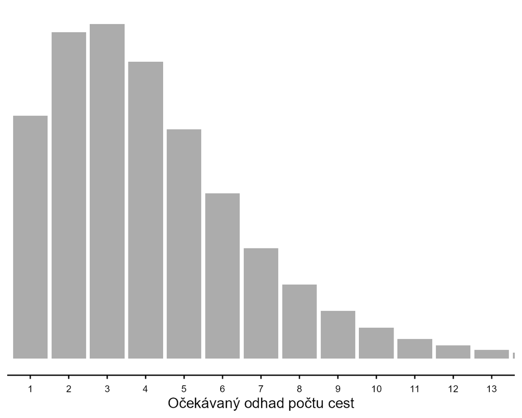

```r
prior_draws5 |>
  ggplot(aes(predicted)) +
  geom_bar(alpha = 0.5) +
  scale_x_continuous(
    breaks = breaks_width(1),
    name = "Očekávaný odhad počtu cest"
  ) +
  coord_cartesian(xlim = c(1, 13)) +
  labs(y = NULL) +
  theme_dist
```

### Fit

**Kód**

```r
prior5 <- c(
  prior1,
  set_prior("normal(0.01, 0.1)", class = "b", coef = "lr"),
  # fmt: skip
  set_prior("student_t(3, 0, 0.1)", class = "sd", coef = "Intercept", group = "id"),
  set_prior("student_t(3, 0, 0.1)", class = "sd", coef = "p", group = "id"),
  set_prior("student_t(3, 0, 0.1)", class = "sd", coef = "t", group = "id"),
  set_prior("student_t(3, 0, 0.1)", class = "sd", coef = "lr", group = "id")
)

fit5 <- brm(
  formula = bf(
    # fmt: skip
    response | trunc(lb = 1) ~ 0 + Intercept + p + t + lr + (1 + p + t + lr || id)
  ),
  data = d,
  family = poisson(),
  prior = prior5,
  iter = 4000,
  warmup = 2000,
  seed = 42,
  file = here("results/fits/fit5.rds"),
  control = list(adapt_delta = 0.99)
)
```

**Kód**

```r
fit5 |>
  as_draws_df() |>
  subset_draws(variable = "^b_|^sd_", regex = TRUE) |>
  summarize_draws() |>
  select(!c(3, 5)) |>
  kable_apa(
    col.names = c(
      "Parametr",
      "Průměr",
      "SD",
      "Q2.5",
      "Q97.5",
      "Rhat",
      "ESS_bulk",
      "ESS_tail"
    ),
  )
```

Tabulka 4

Parametry pátého modelu

| variable | mean | sd | q5 | q95 | rhat | ess_bulk | ess_tail |
| --- | --- | --- | --- | --- | --- | --- | --- |
| b_Intercept | 0.90 | 0.06 | 0.82 | 1.02 | 1 | 2956 | 2324 |
| b_p | 0.36 | 0.06 | 0.26 | 0.45 | 1 | 2848 | 3364 |
| b_t | 0.05 | 0.05 | -0.03 | 0.13 | 1 | 4035 | 3955 |
| b_lr | 0.20 | 0.05 | 0.11 | 0.28 | 1 | 5178 | 3969 |
| sd_id__Intercept | 0.10 | 0.06 | 0.02 | 0.21 | 1 | 2552 | 2683 |
| sd_id__p | 0.10 | 0.06 | 0.04 | 0.20 | 1 | 2947 | 3340 |
| sd_id__t | 0.09 | 0.05 | 0.03 | 0.18 | 1 | 2501 | 1899 |
| sd_id__lr | 0.06 | 0.05 | 0.00 | 0.16 | 1 | 3411 | 3523 |

**Kód**

Obrázek 16

Prior (šedě) vs. posterior (modře)

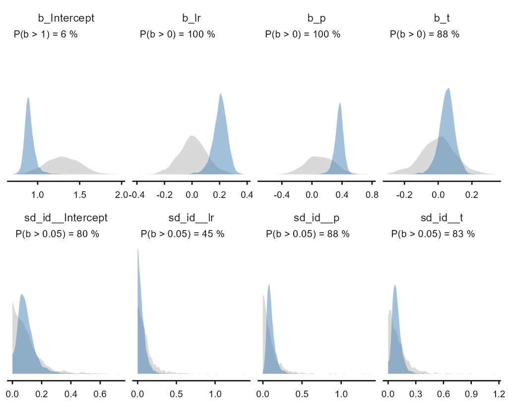

```r
draws5 <- as_draws_df(fit5)

params5 <-
  draws5 |>
  gather_rvars(
    b_Intercept,
    b_p,
    b_t,
    b_lr,
    sd_id__Intercept,
    sd_id__p,
    sd_id__t,
    sd_id__lr
  ) |>
  mutate(
    threshold = case_when(
      .variable == "b_Intercept" ~ 1,
      str_detect(.variable, "^sd_") ~ 0.05,
      .default = 0
    )
  ) |>
  mutate(p_pos = mean(.value > threshold)) |>
  mutate(
    label = str_glue(
      "P(b > {threshold}) = {round(p_pos, 2)*100} %"
    )
  )

bind_rows(
  Prior = prior_draws5 |>
    distinct(.draw, .keep_all = TRUE) |>
    select(
      b_Intercept,
      b_p,
      b_t,
      b_lr,
      sd_id__Intercept,
      sd_id__p,
      sd_id__t,
      sd_id__lr
    ) |>
    as_draws_df() |>
    gather_draws(
      b_Intercept,
      b_p,
      b_t,
      b_lr,
      sd_id__Intercept,
      sd_id__p,
      sd_id__t,
      sd_id__lr
    ),
  Posterior = draws5 |>
    gather_draws(
      b_Intercept,
      b_p,
      b_t,
      b_lr,
      sd_id__Intercept,
      sd_id__p,
      sd_id__t,
      sd_id__lr
    ),
  .id = "source"
) |>
  ggplot(aes(x = .value, fill = source)) +
  stat_slab(alpha = 0.5) +
  geom_text(
    data = params5,
    aes(label = label),
    x = -Inf,
    y = Inf,
    hjust = -0.1,
    vjust = 1.3,
    inherit.aes = FALSE,
    size = 3
  ) +
  scale_fill_manual(
    values = c(Prior = "grey70", Posterior = "steelblue"),
    guide = "none"
  ) +
  facet_wrap(vars(.variable), nrow = 2, scales = "free_x") +
  labs(x = NULL, y = NULL, fill = NULL) +
  theme_dist
```

**Kód**

Obrázek 17

Analýza citlivosti prioru – fixed effects

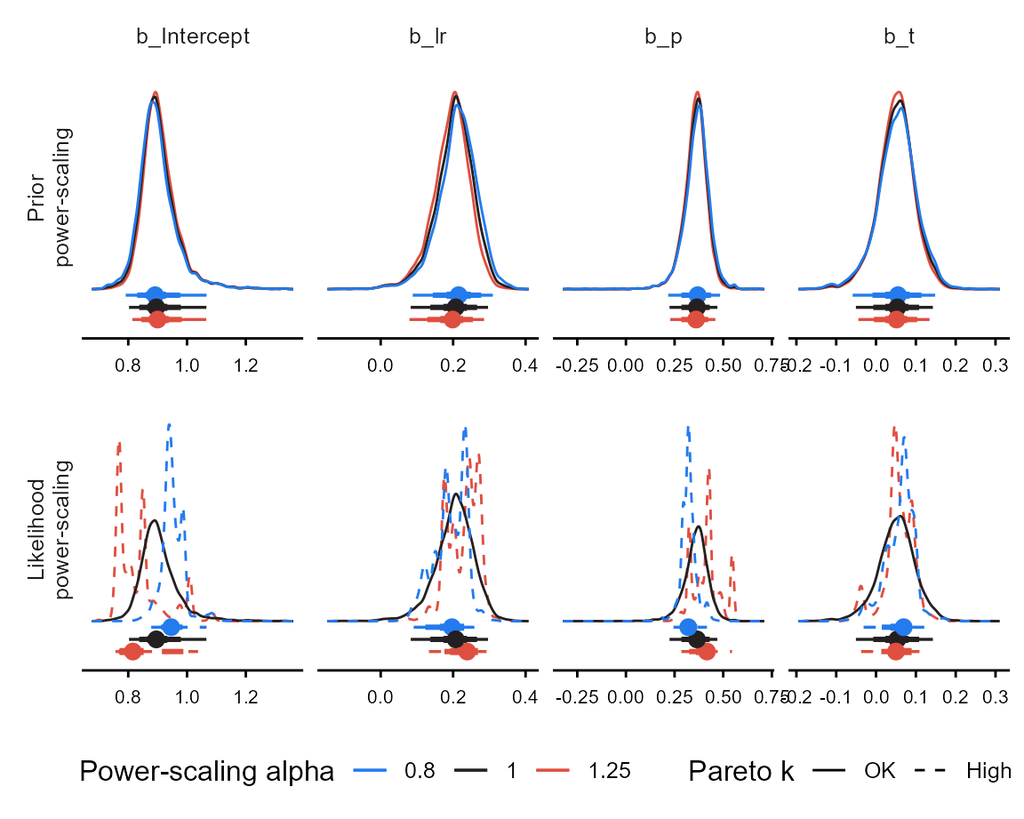

```r
powerscale_plot_dens(
  fit5,
  variable = c(
    "b_Intercept",
    "b_p",
    "b_t",
    "b_lr"
  ),
  help_text = FALSE
)
```

**Kód**

Obrázek 18

Analýza citlivosti prioru – individuální odchylky

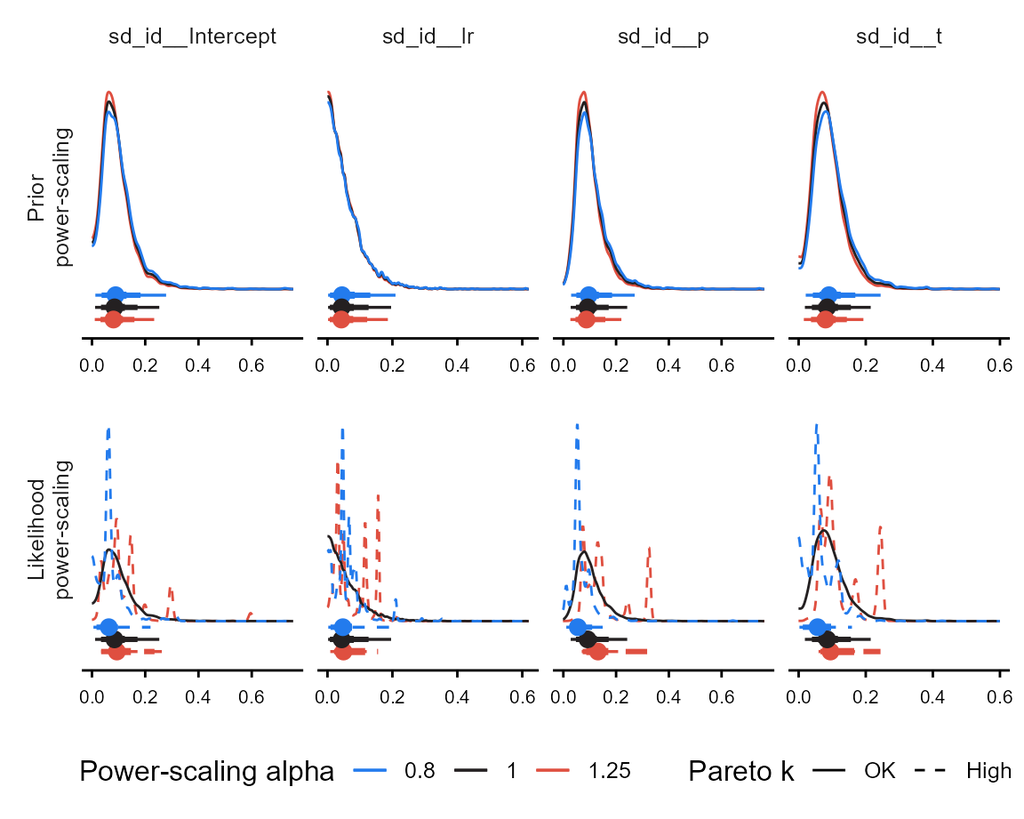

```r
powerscale_plot_dens(
  fit5,
  variable = c(
    "sd_id__Intercept",
    "sd_id__p",
    "sd_id__t",
    "sd_id__lr"
  ),
  help_text = FALSE
)
```

**Kód**

```r
powerscale5 <- powerscale_sensitivity(
  fit5,
  variable = c(
    "b_Intercept",
    "b_p",
    "b_t",
    "b_lr",
    "sd_id__Intercept",
    "sd_id__p",
    "sd_id__t",
    "sd_id__lr"
  )
)

powerscale5 |>
  kable_apa()
```

Tabulka 5

Analýza citlivosti prioru

| variable | prior | likelihood | diagnosis |
| --- | --- | --- | --- |
| b_Intercept | 0.06 | 0.60 | potential prior-data conflict |
| b_p | 0.05 | 0.38 | potential prior-data conflict |
| b_t | 0.05 | 0.11 | potential prior-data conflict |
| b_lr | 0.11 | 0.33 | potential prior-data conflict |
| sd_id__Intercept | 0.15 | 0.56 | potential prior-data conflict |
| sd_id__p | 0.17 | 0.35 | potential prior-data conflict |
| sd_id__t | 0.18 | 0.33 | potential prior-data conflict |
| sd_id__lr | 0.11 | 0.32 | potential prior-data conflict |

**Kód**

Obrázek 19

Priorní (šedě) vs. posteriorní predikce (modře) počtu cest

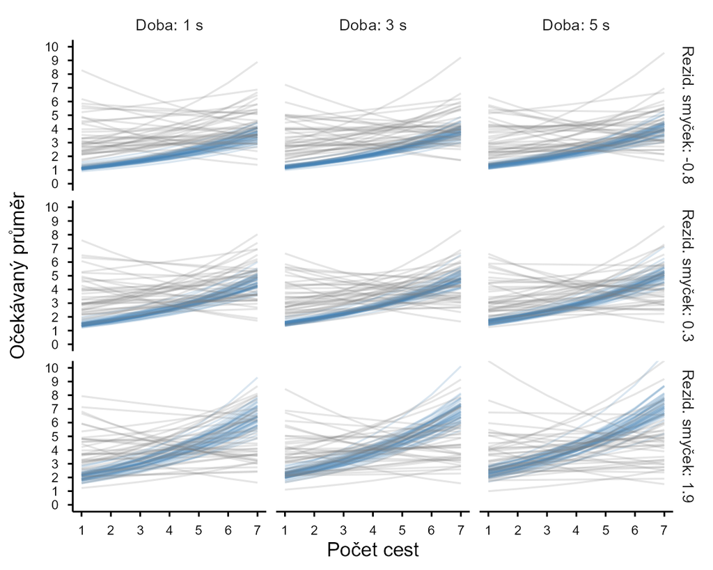

```r
post_draws5 <-
  draws5 |>
  expand_grid(p = p_vals, t = t_vals, lr = lr_vals) |>
  mutate(
    linpred = b_Intercept + b_p * p + b_t * t + b_lr * lr,
    epred = exp(linpred)
  )

prior_draws5_fe <-
  prior_draws5 |>
  distinct(.draw, b_Intercept, b_p, b_t, b_lr) |>
  expand_grid(p = p_vals, t = t_vals, lr = lr_vals) |>
  mutate(
    linpred = b_Intercept + b_p * p + b_t * t + b_lr * lr,
    epred = exp(linpred)
  )

bind_rows(
  Prior = prior_draws5_fe |> sample_draws(ndraws = .ndraws),
  Posterior = post_draws5 |> sample_draws(ndraws = .ndraws),
  .id = "source"
) |>
  ggplot(aes(p, epred, group = interaction(.draw, source), color = source)) +
  geom_line(alpha = 0.2) +
  facet_grid(lr ~ t, labeller = labeller(t = lab_t, lr = lab_lr)) +
  scale_x_continuous(breaks = p_vals, labels = p_labels, name = "Počet cest") +
  scale_y_continuous(breaks = breaks_width(1), name = "Očekávaný průměr") +
  scale_color_manual(
    values = c(Prior = "grey50", Posterior = "steelblue"),
    guide = "none"
  ) +
  coord_cartesian(ylim = c(0, 10)) +
  labs(color = NULL)
```

**Kód**

Obrázek 20

Očekávání modelu s intervaly

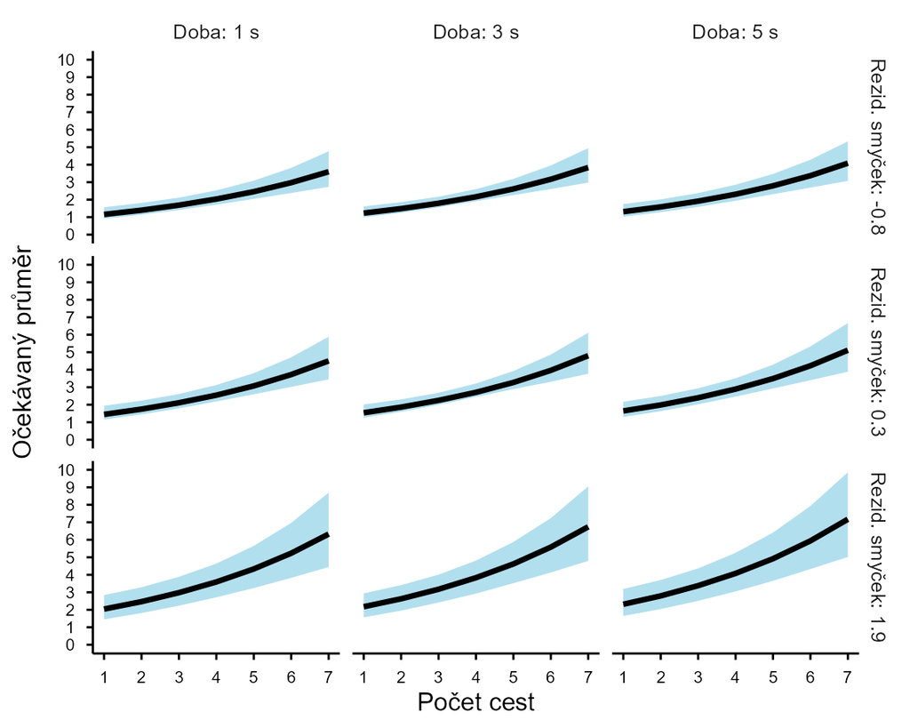

```r
post_draws5 |>
  ggplot(aes(p, epred)) +
  stat_lineribbon(.width = 0.95, fill = "lightblue2") +
  facet_grid(lr ~ t, labeller = labeller(t = lab_t, lr = lab_lr)) +
  scale_x_continuous(breaks = p_vals, labels = p_labels, name = "Počet cest") +
  scale_y_continuous(breaks = breaks_width(1), name = "Očekávaný průměr") +
  coord_cartesian(ylim = c(0, 10)) +
  labs(color = NULL)
```

Jak lze vidět na Obrázek 19 a Obrázek 20, model vnímá jednoznačně rostoucí trend v počtu cest.

Se zvyšujícím se časem se dle modelu zvyšuje i rozptyl, což jde proti naší původní hypotéze o vyšší přesnosti při delším časovém úseku.

**Kód**

Obrázek 21

Posteriorní predikce (tmavě) vs. reálná data (světlé sloupce)

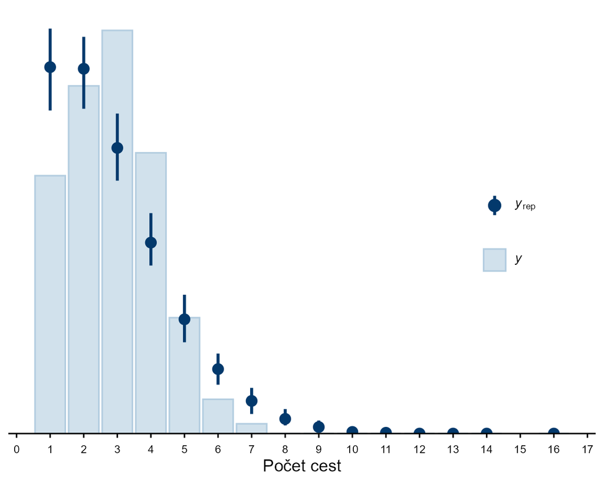

```r
pp_check(fit5, type = "bars", ndraws = 200) +
  scale_x_continuous(breaks = breaks_width(1), name = "Počet cest") +
  theme_dist +
  theme(legend.position = "inside", legend.justification = c(0.9, 0.5))
```

## PSIS-LOO

Při porovnání predikční validity modelů pomocí aproximální leave-one-out cross validace dosáhl model č. 5 výrazně lepších výsledků než ostatní modely.

**Kód**

```r
fit1 <- add_criterion(fit1, "loo", save_psis = TRUE)
fit2 <- add_criterion(fit2, "loo", save_psis = TRUE)
fit3 <- add_criterion(fit3, "loo", save_psis = TRUE)
# fit4 <- add_criterion(fit4, "loo", save_psis = TRUE)
fit5 <- add_criterion(fit5, "loo", save_psis = TRUE)

loo_compare(fit1, fit2, fit3, fit5) |>
  as_tibble(rownames = "model") |>
  select(1:3) |>
  kable_apa()
```

Tabulka 6

Porovnání predikčních schopností modelu pomocí LOO

| model | elpd_diff | se_diff |
| --- | --- | --- |
| fit5 | 0.0 | 0.00 |
| fit3 | -25.1 | 4.65 |
| fit2 | -48.9 | 6.30 |
| fit1 | -394.2 | 12.07 |

# Limitace

- Interval 5 s pro odpověď zkresluje efekt doby prezentace stimulů.
- Nedostatek dat pro komplexnější modil odlišující různé strategie (hádání vs. počítání).